# Introduction to Linear Regression

Linear regression is a supervised learning algorithm. Given a single feature, a line is fit that best predicts the independent variable. When many features are involved, a hyperplane is fit that minimizes the error between predicted values and the ground truth. Given an input vector Xn = (X1, X2, ..., Xn) that we want to use to predict the output y, the regression equation is given by:

$$y=\beta_0 + \sum_{i=1}^nX_i\beta_i$$

As you can see below, the line that minimized the Mean Squared Distance (MSE) is the best fit. Linear Regression is a statistical technique to determine that line.

[figure not shown]

Regression can also involve fitting polynomials as shown below:

[figure not shown]

The errors are reduced by minimizing the error squared, where error is the difference between predicted values and the target values. The linear regression course is organized as:

- Study of Boston Housing Price dataset.
- EDA - Scatter plots, joint plots
- Categorical variables
- Regression using Statsmodels
- Improving the fit
  - R-squared
  - P-values
  - Multi-collinearity
- Regression using Scikit-Learn
- Lasso
- Ridge
- Cross-Validation

# Instructions

Boston dataset can be loaded from the datasets in Scikit-Learn with the command load_boston(). To work with linear regression datasets, we need the libraries numpy, pandas and seaborn. For modeling, we would need statsmodels or sklearn. sklearn has datasets property which facilitates easy loading of popular datasets such as the Boston Housing price dataset. You can use the load_boston() function to load the datasets. The features are available in feature_names list. We can feed this data into a dataframe to use statsmodels or sklearn for regression modeling.

- Slice the top 10 rows of the boston_data dataframe and assign it to boston_sample

```python
from sklearn import datasets
from matplotlib import rcParams

import numpy as np
import pandas as pd
import seaborn as sns

#Set graph fonts
rcParams['font.family'] = 'DejaVu Sans'

#load boston dataset
boston_dataset = datasets.load_boston()
boston_data = pd.DataFrame(boston_dataset.data, columns=boston_dataset.feature_names)
boston_sample = boston_data.head(10)
boston_sample
```

|  | CRIM | ZN | INDUS | CHAS | NOX | RM | AGE | DIS | RAD | TAX | PTRATIO | B | LSTAT |
| --- | --- | --- | --- | --- | --- | --- | --- | --- | --- | --- | --- | --- | --- |
| 0 | 0.00632 | 18.0 | 2.31 | 0.0 | 0.538 | 6.575 | 65.2 | 4.0900 | 1.0 | 296.0 | 15.3 | 396.90 | 4.98 |
| 1 | 0.02731 | 0.0 | 7.07 | 0.0 | 0.469 | 6.421 | 78.9 | 4.9671 | 2.0 | 242.0 | 17.8 | 396.90 | 9.14 |
| 2 | 0.02729 | 0.0 | 7.07 | 0.0 | 0.469 | 7.185 | 61.1 | 4.9671 | 2.0 | 242.0 | 17.8 | 392.83 | 4.03 |
| 3 | 0.03237 | 0.0 | 2.18 | 0.0 | 0.458 | 6.998 | 45.8 | 6.0622 | 3.0 | 222.0 | 18.7 | 394.63 | 2.94 |
| 4 | 0.06905 | 0.0 | 2.18 | 0.0 | 0.458 | 7.147 | 54.2 | 6.0622 | 3.0 | 222.0 | 18.7 | 396.90 | 5.33 |
| 5 | 0.02985 | 0.0 | 2.18 | 0.0 | 0.458 | 6.430 | 58.7 | 6.0622 | 3.0 | 222.0 | 18.7 | 394.12 | 5.21 |
| 6 | 0.08829 | 12.5 | 7.87 | 0.0 | 0.524 | 6.012 | 66.6 | 5.5605 | 5.0 | 311.0 | 15.2 | 395.60 | 12.43 |
| 7 | 0.14455 | 12.5 | 7.87 | 0.0 | 0.524 | 6.172 | 96.1 | 5.9505 | 5.0 | 311.0 | 15.2 | 396.90 | 19.15 |
| 8 | 0.21124 | 12.5 | 7.87 | 0.0 | 0.524 | 5.631 | 100.0 | 6.0821 | 5.0 | 311.0 | 15.2 | 386.63 | 29.93 |
| 9 | 0.17004 | 12.5 | 7.87 | 0.0 | 0.524 | 6.004 | 85.9 | 6.5921 | 5.0 | 311.0 | 15.2 | 386.71 | 17.10 |

### Solution

```
boston_sample = boston_data.head(10)
boston_sample
```

# Boston Housing Dataset - EDA

The data and target are present as properties in boston data. Statsmodels is a library used popularly for linear regression. Boston data is present as independent variables in data and the housing rate as MEDV in target property. Also feature names are listed in feature_names. The desription is available in UCI Machine Learning repository website.

Boston Housing Dataset

| CRIM | per capita crime rate by town |
| --- | --- |
| ZN | proportion of residential land zoned for lots over 25,000 sq.ft. |
| INDUS | proportionof non-retail business acres per town |
| CHAS | Charles River dummy variable (= 1 if tract bounds river; 0 otherwise) |

The task is to model the median value of owner-occupied homes given all the factors. Some factors could affect the housing value and some may not.

# Scatter Plots or Joint plots using seaborn

To visualize how each factor would affect housing rate, we can run a scatter plot of the housing rate for each dependent variable. This will help visualize how the target vector may be affected by each factor. Later we shall study quantitave methods that can provide us methods to measure how each factor affects the output or if it doesnt affect the output at all.

g = sns.jointplot("MEDV", "CRIM", data=df, xlim=(0, 60), ylim=(0, 12), color="r", size=7)

[figure not shown]

From the above plot we can observe that the median value of the houses in Boston peaks at lowest crime rates which makes logical sense. This is one of the goals of EDA; to discover patterns in scatter plots and make sense of the input variables. The input variables are also called indepedent variables since they affect the value of the target variable, which is called the dependent variable.

#### Instructions

- Generate a joint plot of Boston house prices vs Lower status of the population and assign the plot to variable g as shown in the demo code below.
- What is your interpretation of the scatter plot?

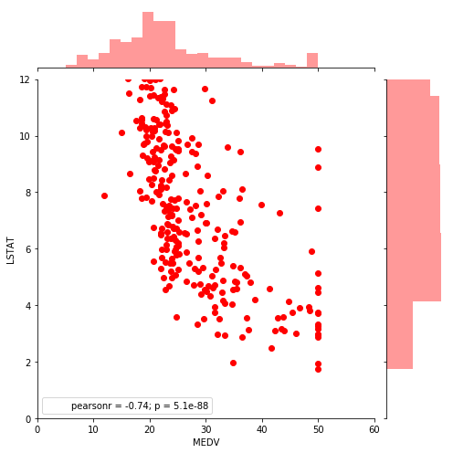

```python
from sklearn import datasets, linear_model
import statsmodels.formula.api as sm

boston_data['MEDV'] = boston_dataset.target

# Modify this to plot MEDV vs Lower status of the population.
g = sns.jointplot("MEDV", "LSTAT", data=boston_data, xlim=(0, 60), ylim=(0, 12), color="r", size=7)
```

### Solution

Look up the symbol for Lower status of the population.

```
g = sns.jointplot("MEDV", "LSTAT", data=boston_data, xlim=(0, 60), ylim=(0, 12), color="r", size=7)
```

## Categorical Variables

We can now look at scatter plots of all input variables with seaborn:

[figure not shown]

The above is helpful to visualize what factors might be significant. However, there are quantitative tests that we shall learn to verify our assumptions.

# Categorical Variables

In Fig. 2 the feature CHAS only takes two values 0.0 and 1.0. It is essentialy a boolean value as described in the table as well. Note that when descriptions are not available, we can still look at unique value of a feature or plot graphs to discover such occurences. This feature indicates Charles river proximity in a certain manner. Such variables that take boolean values or variables such as day of the week which can take a range of unique values are called as categorical variables. There are better plots to visualize such variables. While selecting categorical variables it is important that the fraction of unique values is relatively small compared to the total dataset. To visualize the categorical data, we can use stripplot:

```
sns.stripplot(x="CHAS", y="MEDV", data=boston_data);
With seaborn, you can adjust the plots with the settings buttons at the bottom.
```

[figure not shown]

The joint plots and scatter plots by default overlap the points and therefore to visualize density becomes a tough task, esp when such overlapping points are high in the map. To resolve this issue, you can set the flag called jitter to True which spreads high density of overlapping points.

[figure not shown]

### Instructions

To identify categorical variables, you can study the scatter plots to see a fixed set of limited values or can look up the unique values in the feature with the command:

```
boston_data['CHAS'].unique()
array([ 0.,  1.])
```

- Identify the other categorical variable in the dataset and generate a stripplot against MEDV setting jitter to True.

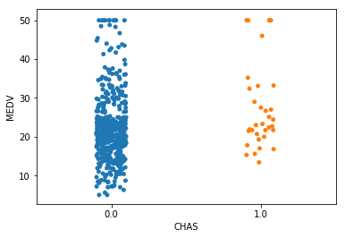

```python
boston_data['RAD'].unique()
g = sns.stripplot(x="CHAS", y="MEDV", data=boston_data, jitter=True)
```

### Solution

Lookup the graph and print out the array of all the unique values. If the values are limited and much lesser than the total dataset size then it is a categorical variable.

```
boston_data['RAD'].unique()
g = sns.stripplot(x="RAD", y="MEDV", data=boston_data, jitter=True)
```

# Regression Using Statsmodels

Statsmodels is a library used widely for linear regression. The linear regression library has convenient ways to specify parameters for regression and hence is popularly used. The format to specify regression for a single variable is:

```
lm = sm.ols(formula = 'y ~ x')
```

where x is a dependent variable. Let us look at how housing rate is affected by crime rate.

```
lm = sm.ols(formula='MEDV ~ CRIM', data=boston_data).fit()
```

This is called simple regression as only one variable affects the target variable. The above command trains the model lm with input as CRIM and target as MEDV. If many variables are involved in modeling the target, then it is called multiple linear regression.

To get prediction from the trained model:

```
y_hat = lm.predict(boston_data[['CRIM']])
```

## Parameters of Linear Regression

The main parameters of linear regression are the intecept and the coefficients. Print out the main parameters with the command:

lm.params

Intercept 24.016220 CRIM -0.412775 dtype: float64

The coeffecient of CRIM shows the value by which housing rate changes for every unit increase in crime rate. Since it is negative, we can interpret that for every unit incrase in crime rate, the housing rate declines by -0.412775.

The most important parameter to look for is the mean squared error, which tells us how good the predictions matched the ground truth or the target variable.

```
print("MSE:", mean_squared_error(boston_data['MEDV'].values, y_hat))
MSE: 71.8523466653
```

### Instructions

- Build a model of Housing price for input as average number of rooms per dwelling.
- Run prediction on the trained model. Assign the predictions to y_hat.
- What is the MSE? Assign the mean squared error to mse_lm

```python
from sklearn.metrics import mean_squared_error

# Modify this to incorporate average number of rooms per dwelling as an input.
```

### Solution Code

```
lm = sm.ols(formula='MEDV ~ RM', data=boston_data).fit()
y_hat = lm.predict(boston_data[['RM']])
mse_lm = mean_squared_error(y_hat, boston_data[['RM']])
print("MSE:", mean_squared_error(y_hat, boston_data[['MEDV']]))
```

# Improving the Fit - R-squared & Feature Engineering

'Improving the fit' or 'Fine tuning the model' are popular terms amongst data scientists. These terms refer to manipulating various parameters of linear regression model inputs as well as certain practices that enhance the predictions. We shall now study various such steps that are involved in improving the fit, thereby reducing the MSE.

There are other output parameters of linear regression that can be seen with the command:

lm.summary()

OLS Regression Results

| Dep. Variable: | MEDV | R-squared: | 0.484 |
| --- | --- | --- | --- |
| Model: | OLS | Adj. R-squared: | 0.483 |
| Method: | Least Squares | F-statistic: | 471.8 |
| Date: | Fri, 09 Jun 2017 | Prob (F-statistic): | 2.49e-74 |
| Time: | 01:26:36 | Log-Likelihood: | -1673.1 |
| No. Observations: | 506 | AIC: | 3350. |
| Df Residuals: | 504 | BIC: | 3359. |
| Df Model: | 1 |  |  |
| Covariance Type: | nonrobust |  |  |